# FN Peru-only model diagnostics

Published

June 5, 2026

Rendered 05 June 2026, 19:46 PDT

# 1 Purpose

This document is a focused diagnostic for the `FN` Peru-only test model. Both runs use the same single-stock configuration with FarNorth catch, FarNorth length composition data from `0.15.dat`, and the two Peruvian CPUE indices (`Peru_Artis` and `Peru_Ind`). The base run uses the default `jjm` behavior, while the `FN_selblocks` run estimates the fitted model with FarNorth selectivity allowed to change in 1980, 1999, 2010, and 2020. The fitted-model comparison below focuses on the rerun `FN` and `FN_selblocks` outputs.

Table 1: FN run configurations read from the active assessment outputs.

| model | label | msy_sel_argument | data_file | stocks | fisheries | fishery_names | indices | index_names | fishery_age_comp_years | fishery_length_comp_years | end_year | n_parameters | nll | max_gradient |
| --- | --- | --- | --- | --- | --- | --- | --- | --- | --- | --- | --- | --- | --- | --- |
| FN | FN base | default | FN.dat | 1 | 1 | FarNorth | 2 | Peru_Artis, Peru_Ind | 0 | 54 | 2025 | 618 | 623.5526 | 0.00014 |
| FN_selblocks | FN selectivity blocks | default | FN.dat | 1 | 1 | FarNorth | 2 | Peru_Artis, Peru_Ind | 0 | 54 | 2025 | 177 | 544.5005 | 0.00010 |

Table 2: Transposed fitted-model comparison for FN and FN_selblocks. NLL components are read from the reported likelihood-component block; SDNR values are computed from the reported standardized residuals for each Peruvian CPUE index.

| Metric | FN base | FN selectivity blocks |
| --- | --- | --- |
| Estimated parameters | 618.00000 | 177.00000 |
| Total NLL | 623.55256 | 544.50049 |
| Delta total NLL | 79.05207 | 0.00000 |
| Catch biomass NLL | 0.28938 | 0.07382 |
| Fishery age-composition NLL | 0.00000 | 0.00000 |
| Fishery length-frequency NLL | 471.63500 | 475.85400 |
| Index NLL | 9.59660 | 13.40400 |
| Survey age-composition NLL | 0.00000 | 0.00000 |
| Survey length-frequency NLL | 0.00000 | 0.00000 |
| Fishery selectivity penalty | 113.69600 | 53.70860 |
| Survey selectivity penalty | 0.00000 | 0.00000 |
| Recruitment penalty | 27.76630 | 1.28571 |
| F penalty | 0.15733 | 0.10211 |
| Index q prior penalty | 0.01044 | 0.05407 |
| Other prior penalty | 0.00000 | 0.00000 |
| Residual | 0.40131 | 0.01836 |
| Maximum gradient | 0.00014 | 0.00010 |
| Mean index SDNR | 0.63319 | 0.77599 |
| Peru Artis SDNR | 0.55494 | 0.75913 |
| Peru Ind SDNR | 0.71144 | 0.79285 |

# 2 Fitted Model Comparisons

The diagnostics in this section compare the model predictions from the rerun `FN` and `FN_selblocks` fits.

## 2.1 Catch Biomass

The catch biomass panel compares the observed FarNorth catch biomass from the active data file with the fitted catch biomass from the `FN` and `FN_selblocks` runs.

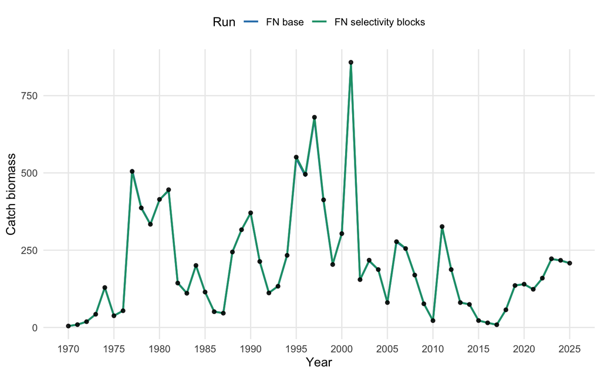

Figure 1: Observed and predicted FarNorth catch biomass by year for the FN and FN_selblocks runs.

## 2.2 Index Fits

Points and vertical intervals show the observed Peruvian CPUE values and nominal 95% intervals from the active data file. Lines show the fitted values from the `FN` and `FN_selblocks` runs.

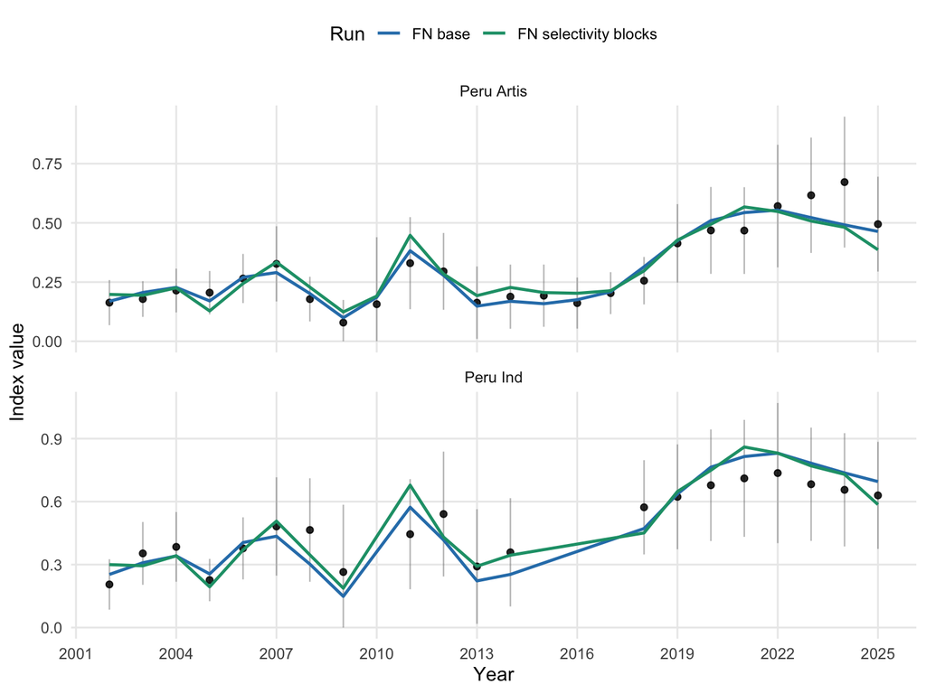

Figure 2: FN and FN_selblocks fits to the Peruvian artisanal and industrial CPUE indices.

## 2.3 Catch-At-Length Fits

The FarNorth catch-at-length panels show observed length proportions as bars or black points and fitted proportions from the `FN` and `FN_selblocks` runs.

**Aggregate By Period**

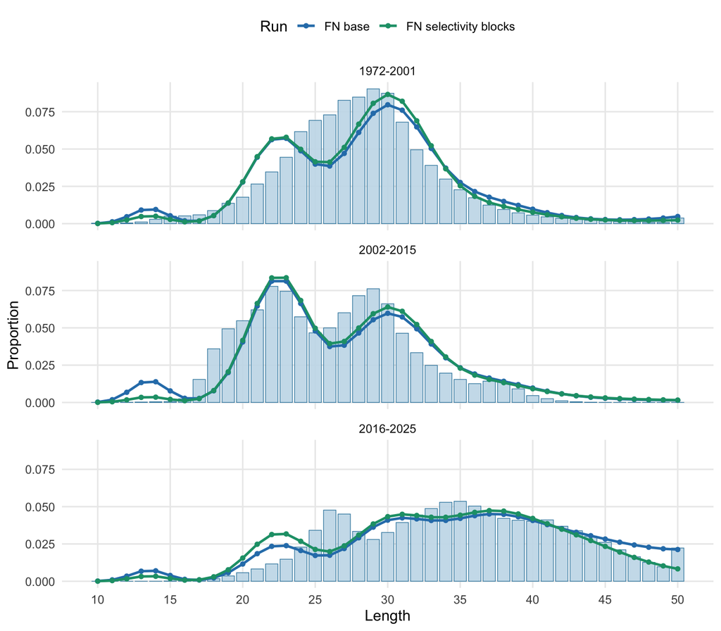

Figure 3: Sample-size-weighted aggregate FarNorth catch-at-length fits for the FN and FN_selblocks runs.

**Recent Years**

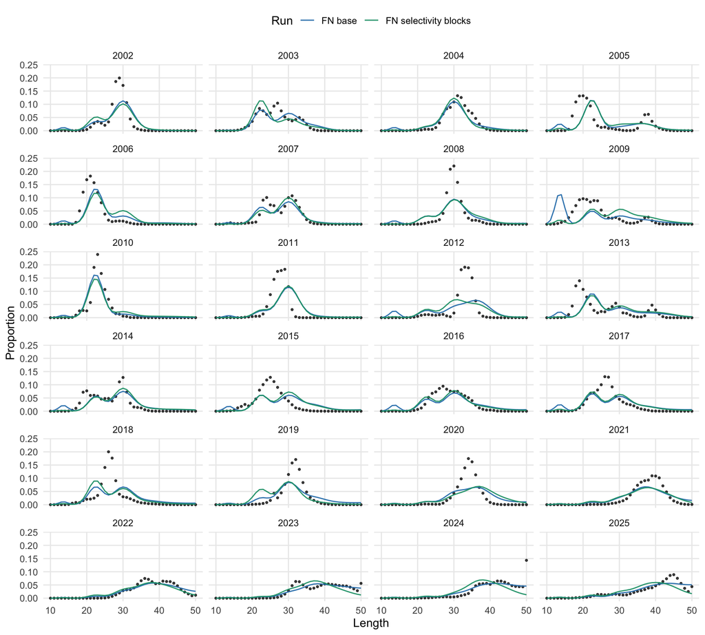

Figure 4: Recent annual FarNorth catch-at-length fits for the FN and FN_selblocks runs.

**All Years**

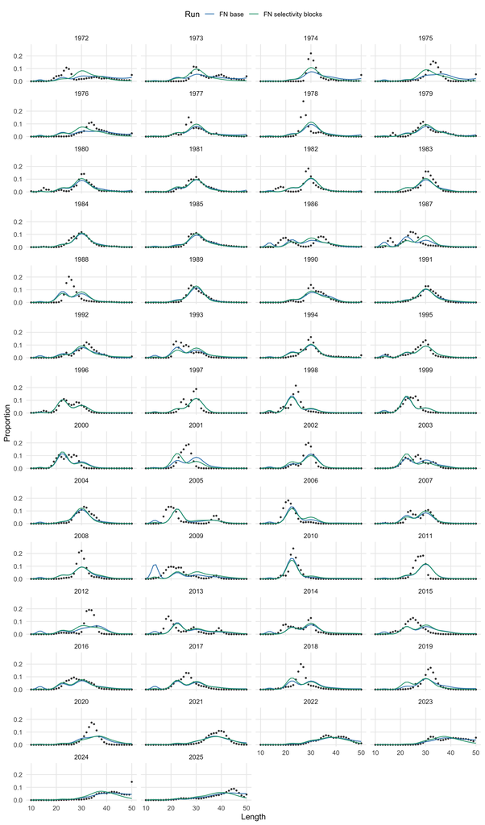

Figure 5: All annual FarNorth catch-at-length fits for the FN and FN_selblocks runs.